# hw4

Tanner Boyle

3/3/2020

## PROBLEM 1:

```r
print(weight0)
```

```
##   Diet   n avg_weight       sd
## 1    1 220   102.6455 56.65655
## 2    2 120   122.6167 71.60749
## 3    3 120   142.9500 86.54176
## 4    4 118   135.2627 68.82871
```

## PROBLEM 2

```r
print(head(complete, 3))
```

```
##   weight Time Chick Diet
## 1     42    0     1    1
## 2     51    2     1    1
## 3     59    4     1    1
```

## PROBLEM 3

```r
print(head(complete, 3))
```

```
## # A tibble: 3 x 5
## # Groups:   Chick [1]
##   weight  Time Chick Diet  weightgain
##    <dbl> <dbl> <ord> <fct>      <dbl>
## 1     42     0 1     1              0
## 2     51     2 1     1              9
## 3     59     4 1     1             17
```

## PROBLEM 4

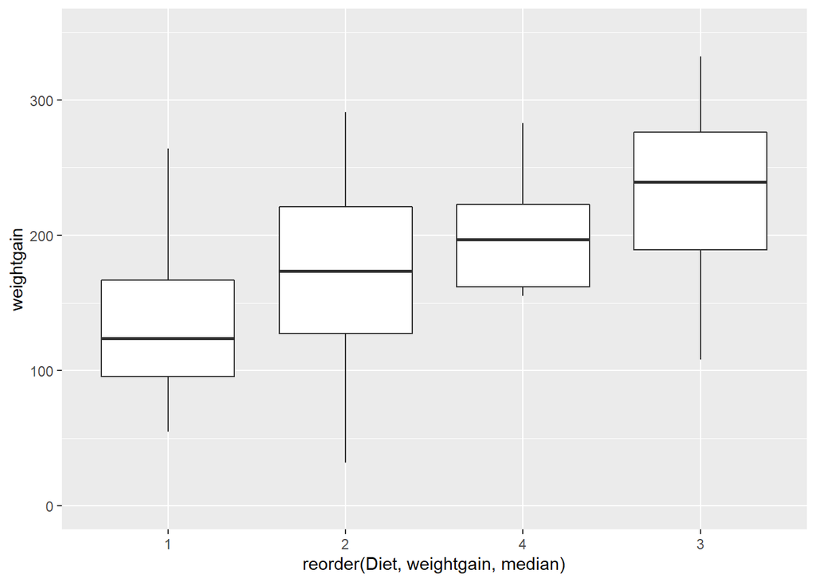

```r
complete %>%
  filter(Time == 21) %>%
  ggplot(aes(x=reorder(Diet, weightgain, median), y=weightgain)) +
  geom_boxplot() +
  ylim(c(0, 350))
```

### There seems to be a diet effect. In order from least to most weight gain (as ordered by median weight gain of each diet), we see diets 1, 2, 4, 3. Interestingly, Diet 4 appears to have the most precise data (smallest IQR and overall range), and Diet 2 appears to have the largest spread (both IQR and overall range).

## PROBLEM 5

```r
complete %>%
  filter(Time == 21) %>%
  arrange(-weightgain) %>%
  tail(1)
```

```
## # A tibble: 1 x 5
## # Groups:   Chick [1]
##   weight  Time Chick Diet  weightgain
##    <dbl> <dbl> <ord> <fct>      <dbl>
## 1     74    21 24    2             32
```

```r
complete %>%
  filter(Time == 21) %>%
  arrange(-weightgain) %>%
  head(1)
```

```
## # A tibble: 1 x 5
## # Groups:   Chick [1]
##   weight  Time Chick Diet  weightgain
##    <dbl> <dbl> <ord> <fct>      <dbl>
## 1    373    21 35    3            332
```

## PROBLEM 6

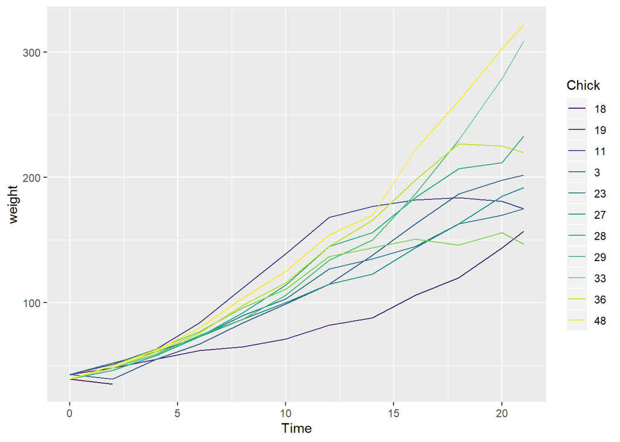

```r
complete %>%
  filter(Chick %in% c(3, 11, 19, 23, 18, 27, 28, 29, 33, 36, 48)) %>%
  ggplot(aes(x=Time, y=weight, group=Chick, color=Chick)) +
  geom_line()
```

### After determining which chicks had the highest/lowest starting weights (there were multiple that were tied at 43gm and 39gm, respectively), I plotted the weight trajectory of each one. Apart from two outliers (the purple lines that form a sort of oval), the chicks all had similar growth trajectories. This supports the idea that initial weight doesn’t impact rate of growth (at least through 10-15 days). It would appear to me like the growth rate of any given chick is likely to be quadratic, with faster growth coming later on in their lifespan.

## PROBLEM 7

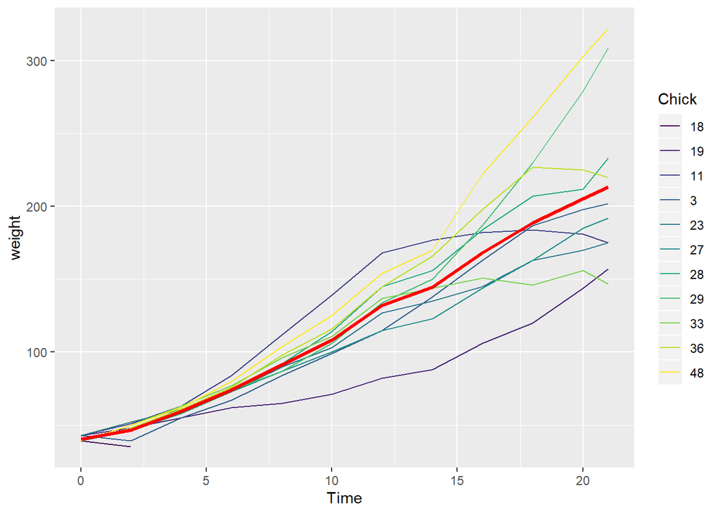

```r
complete %>%
  filter(Chick %in% c(3, 11, 19, 23, 18, 27, 28, 29, 33, 36, 48)) %>%
  ggplot(aes(x=Time, y=weight, group=Chick, color=Chick)) +
  geom_line() +
  stat_summary(aes(y=weight,group=1), fun.y=mean, colour="red", geom="line", size=1.125, group=1)
```

### Again, apart from the two outlier chicks colored in purple, it seems like most chicks are quite similar to the average chick, further supporting the idea that initial weight doesn’t play a major role in rate of growth (when averaged across all diets).

## PROBLEM 8

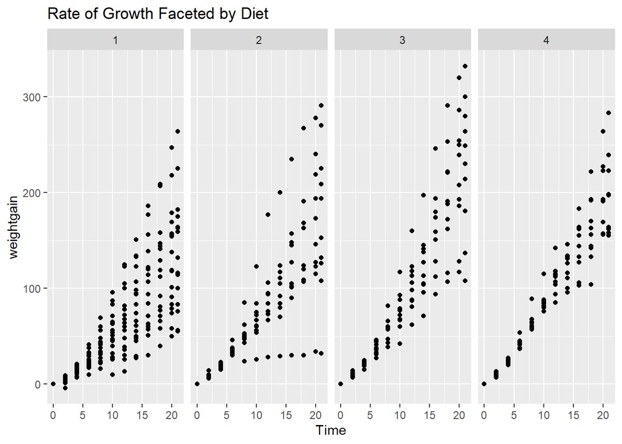

```r
complete %>%
  ggplot(aes(x=Time, y=weightgain)) +
  geom_point() +
  facet_grid(~Diet) +
  ggtitle("Rate of Growth Faceted by Diet")
```

```r
model <- lm(weight ~ Time + Diet, data = ChickWeight)
summary(model)
```

```
##
## Call:
## lm(formula = weight ~ Time + Diet, data = ChickWeight)
##
## Residuals:
##      Min       1Q   Median       3Q      Max
## -136.851  -17.151   -2.595   15.033  141.816
##
## Coefficients:
##             Estimate Std. Error t value Pr(>|t|)
## (Intercept)  10.9244     3.3607   3.251  0.00122 **
## Time          8.7505     0.2218  39.451  < 2e-16 ***
## Diet2        16.1661     4.0858   3.957 8.56e-05 ***
## Diet3        36.4994     4.0858   8.933  < 2e-16 ***
## Diet4        30.2335     4.1075   7.361 6.39e-13 ***
## ---
## Signif. codes:  0 '***' 0.001 '**' 0.01 '*' 0.05 '.' 0.1 ' ' 1
##
## Residual standard error: 35.99 on 573 degrees of freedom
## Multiple R-squared:  0.7453, Adjusted R-squared:  0.7435
## F-statistic: 419.2 on 4 and 573 DF,  p-value: < 2.2e-16
```

```r
ChickWeightadj <- ChickWeight
ChickWeightadj$Time2 <- ChickWeightadj$Time * ChickWeightadj$Time

model2 <- lm(weight ~ Time + Diet + Time2, data=ChickWeightadj)
summary(model2)
```

```
##
## Call:
## lm(formula = weight ~ Time + Diet + Time2, data = ChickWeightadj)
##
## Residuals:
##      Min       1Q   Median       3Q      Max
## -146.372  -16.983   -0.684   15.283  132.295
##
## Coefficients:
##             Estimate Std. Error t value Pr(>|t|)
## (Intercept) 21.56559    4.18810   5.149 3.60e-07 ***
## Time         5.42189    0.83037   6.530 1.46e-10 ***
## Diet2       16.08443    4.02910   3.992 7.40e-05 ***
## Diet3       36.41776    4.02910   9.039  < 2e-16 ***
## Diet4       30.28713    4.05041   7.478 2.86e-13 ***
## Time2        0.15615    0.03758   4.155 3.74e-05 ***
## ---
## Signif. codes:  0 '***' 0.001 '**' 0.01 '*' 0.05 '.' 0.1 ' ' 1
##
## Residual standard error: 35.49 on 572 degrees of freedom
## Multiple R-squared:  0.7528, Adjusted R-squared:  0.7506
## F-statistic: 348.3 on 5 and 572 DF,  p-value: < 2.2e-16
```

### With more time, it could be interesting to explore whether there are interaction effects between time and Diets. Perhaps certain diets increase growth rate in early days and certain diets are more effective at increasing growth rate in the later days. Ultimately, I think that the goal would be to predict a final weight after 21 days for any given chick with starting weight W and diet D.